# BGB-USD

## BGB-USD today is +0200, 2025-11-19, 20:41:58

This crypto forecast was generated by gemini-2.0-flash API

## Daily Chart

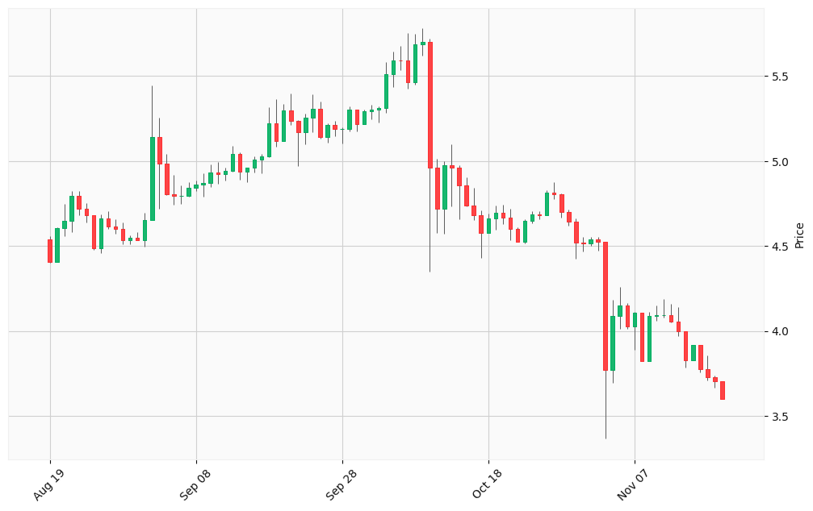

## Hourly Chart

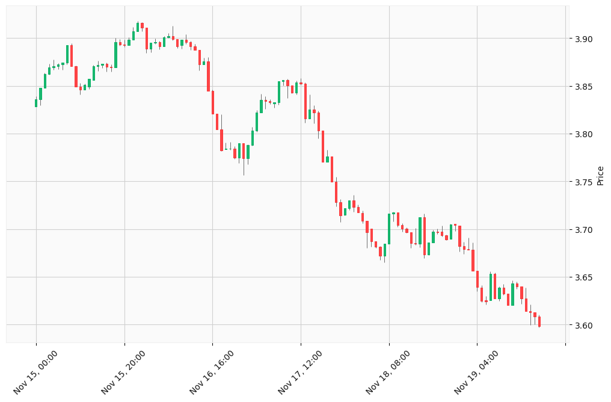

Okay, I will analyze the provided BGB-USD cryptocurrency data and generate buy and sell signals based on the outlined steps. I will use technical analysis on the provided data, and the Google Search Tool for market news and economic factors.

Here’s an analysis of the BGB-USD cryptocurrency, incorporating technical analysis of the provided data and insights from current market news and economic factors:

### Market Data Collection

I will use the provided data, and supplement it with the Google Search results for related news and economic indicators.

### Technical Analysis

#### Daily Chart Analysis (Last Three Months)

  ```python
  import pandas as pd

  daily_data = [
      [4.53885, 4.55702, 4.40033, 4.40445, 136014109],
      [4.40445, 4.61012, 4.40443, 4.60399, 191943213],
      [4.60399, 4.74776, 4.55683, 4.64859, 366611055],
      [4.64859, 4.82336, 4.58268, 4.79376, 419581684],
      [4.79376, 4.82355, 4.68301, 4.72, 142354664],
      [4.72, 4.75404, 4.64008, 4.68014, 161620064],
      [4.68014, 4.68249, 4.47491, 4.48585, 208446660],
      [4.48585, 4.68459, 4.4584, 4.66076, 145969301],
      [4.66076, 4.70464, 4.60095, 4.61244, 148073650],
      [4.61244, 4.65765, 4.57367, 4.60252, 104710899],
      [4.60252, 4.63652, 4.50849, 4.53618, 86761194],
      [4.53618, 4.56364, 4.51083, 4.54989, 52102248],
      [4.54989, 4.5823, 4.53177, 4.53349, 65352634],
      [4.53349, 4.69668, 4.49778, 4.65258, 136072639],
      [4.65258, 5.44464, 4.65005, 5.1398, 666844023],
      [5.1398, 5.25446, 4.72024, 4.98524, 342488126],
      [4.98524, 5.03954, 4.79789, 4.80513, 216389657],
      [4.80513, 4.91896, 4.74034, 4.79367, 206878662],
      [4.79367, 4.85683, 4.74546, 4.79481, 109917795],
      [4.79481, 4.87505, 4.79131, 4.84034, 128030577],
      [4.84034, 4.88368, 4.82254, 4.85918, 181994506],
      [4.85918, 4.92974, 4.78846, 4.87075, 313475627],
      [4.87075, 4.98054, 4.84813, 4.9308, 340988210],
      [4.9308, 4.99162, 4.86382, 4.92511, 182481792],
      [4.92511, 4.96213, 4.88715, 4.94335, 179443826],
      [4.94335, 5.0892, 4.93662, 5.04061, 246513565],
      [5.04061, 5.05017, 4.88909, 4.93883, 216348336],
      [4.93883, 4.96253, 4.87543, 4.9623, 299153325],
      [4.9623, 5.02887, 4.93184, 5.00925, 235628363],
      [5.00925, 5.04054, 4.92838, 5.02646, 281582929],
      [5.02646, 5.31525, 5.02116, 5.22305, 386898122],
      [5.22305, 5.36372, 5.08381, 5.11525, 335202403],
      [5.11525, 5.33398, 5.11525, 5.29742, 205120157],
      [5.29742, 5.39549, 5.21437, 5.23394, 255186090],
      [5.23394, 5.23884, 4.96798, 5.16859, 530699883],
      [5.16859, 5.27823, 5.09795, 5.25454, 279294805],
      [5.25454, 5.39101, 5.16723, 5.30693, 381657089],
      [5.30693, 5.34905, 5.12968, 5.13952, 672350153],
      [5.13952, 5.22027, 5.10591, 5.2116, 415962250],
      [5.2116, 5.23691, 5.14802, 5.18626, 140138539],
      [5.18626, 5.19913, 5.10362, 5.18771, 113268290],
      [5.18771, 5.32284, 5.17326, 5.30231, 289619442],
      [5.30231, 5.30231, 5.17186, 5.21902, 340536802],
      [5.21902, 5.30093, 5.21501, 5.29409, 157753176],
      [5.29409, 5.33171, 5.24302, 5.30127, 180690546],
      [5.30127, 5.32129, 5.22448, 5.31296, 217809588],
      [5.31296, 5.58259, 5.28135, 5.51056, 283164997],
      [5.51056, 5.64428, 5.43632, 5.59319, 316542968],
      [5.59319, 5.67637, 5.53535, 5.5929, 369974473],
      [5.5929, 5.75249, 5.42611, 5.46236, 609893944],
      [5.46236, 5.74846, 5.45029, 5.68715, 573542743],
      [5.68715, 5.78136, 5.62027, 5.69954, 448187453],
      [5.69954, 5.71851, 4.34851, 4.96119, 720155734],
      [4.96119, 5.01334, 4.57702, 4.71793, 704352767],
      [4.71793, 5.00052, 4.57381, 4.97424, 392134818],
      [4.97424, 5.09731, 4.73264, 4.96147, 481142626],
      [4.96147, 4.975, 4.65634, 4.85531, 487159246],
      [4.85531, 4.90159, 4.73384, 4.73932, 248715338],
      [4.73932, 4.84315, 4.65051, 4.6799, 220704951],
      [4.6799, 4.7108, 4.42878, 4.57635, 215011123],
      [4.57635, 4.69114, 4.57634, 4.66389, 17903576],
      [4.66389, 4.73564, 4.59553, 4.69461, 79052782],
      [4.69461, 4.7412, 4.62991, 4.66779, 68395020],
      [4.66779, 4.71831, 4.53226, 4.60036, 74924357],
      [4.60036, 4.60824, 4.52217, 4.52413, 69471765],
      [4.52413, 4.6584, 4.5152, 4.64935, 81806390],
      [4.64935, 4.70316, 4.63338, 4.68401, 86150578],
      [4.68401, 4.70304, 4.65676, 4.68133, 60433596],
      [4.68133, 4.82834, 4.67984, 4.81355, 75046455],
      [4.81355, 4.87371, 4.77761, 4.80323, 90173850],
      [4.80323, 4.80698, 4.66708, 4.69852, 82674113],
      [4.69852, 4.71578, 4.61901, 4.64231, 79896572],
      [4.64231, 4.66214, 4.42535, 4.51776, 66598903],
      [4.51776, 4.55071, 4.46747, 4.51456, 56353410],
      [4.51456, 4.5516, 4.50045, 4.53747, 45392912],
      [4.53747, 4.55508, 4.47206, 4.52405, 51647998],
      [4.52405, 4.52405, 3.3664, 3.76924, 124503929],
      [3.76924, 4.18296, 3.69556, 4.0895, 102974232],
      [4.0895, 4.26063, 4.01279, 4.14863, 56757997],
      [4.14863, 4.16173, 4.01006, 4.02756, 53681919],
      [4.02756, 4.11299, 3.88956, 4.10593, 74675422],
      [4.10593, 4.10594, 3.82165, 3.82165, 64203328],
      [3.82165, 4.10949, 3.82165, 4.08679, 66348930],
      [4.08679, 4.14931, 4.06003, 4.09164, 69748196],
      [4.09164, 4.18551, 4.08019, 4.09195, 69468932],
      [4.09195, 4.15862, 4.04869, 4.05631, 67608701],
      [4.05631, 4.13781, 3.97141, 3.9981, 79708117],
      [3.9981, 3.9981, 3.78645, 3.82841, 87259674],
      [3.82841, 3.91812, 3.82831, 3.916, 65178958],
      [3.916, 3.91695, 3.75624, 3.77442, 71021341],
      [3.77442, 3.85768, 3.70702, 3.72973, 78010917],
      [3.72973, 3.73581, 3.66491, 3.70418, 78288033],
      [3.70418, 3.70418, 3.59843, 3.59843, 73281120]
  ]

  df = pd.DataFrame(daily_data, columns=['Open', 'High', 'Low', 'Close', 'Volume'])

  # Calculate 10-day SMA
  df['SMA_10'] = df['Close'].rolling(window=10).mean()

  # Calculate 20-day SMA
  df['SMA_20'] = df['Close'].rolling(window=20).mean()

    ```python
    def calculate_rsi(data, window=14):
        delta = data['Close'].diff()
        up = delta.clip(lower=0)
        down = -1 * delta.clip(upper=0)

        avg_up = up.rolling(window=window, min_periods=window).mean()
        avg_down = down.rolling(window=window, min_periods=window).mean()

        rs = avg_up / avg_down
        rsi = 100 - (100 / (1 + rs))

        return rsi

  ```python
  def calculate_macd(data, fast_period=12, slow_period=26, signal_period=9):
      ema_fast = data['Close'].ewm(span=fast_period, adjust=False).mean()
      ema_slow = data['Close'].ewm(span=slow_period, adjust=False).mean()
      macd = ema_fast - ema_slow
      signal = macd.ewm(span=signal_period, adjust=False).mean()
      histogram = macd - signal
      return macd, signal, histogram

#### Hourly Chart Analysis (Last Five Days)

- **Trend:** A downward trend is observable in the last five days.
- **Support and Resistance:** Key levels can be identified by looking at the recent highs and lows.

### News and Economic Analysis

- **Market Sentiment:** Recent news indicates a cryptocurrency market selloff due to profit-taking, institutional outflows, and macro uncertainty.
- **Economic Indicators:** Economic indicators such as GDP, inflation, and interest rates can significantly impact the crypto market. Rising interest rates and high inflation typically put downward pressure on crypto prices.
- **BGB-Specific News:** The Morph Foundation announced a new allocation plan for BGB tokens and launched a quarterly burn mechanism. BGB can now be used to pay for Morph network Gas, potentially increasing its utility.

### Scenario Evaluation

- **Bear Market:** Given the recent market selloff and negative sentiment, a bear market scenario seems plausible.
- **High Volatility:** The provided data indicates high volatility in BGB-USD, making it prone to sharp price swings.

### Signal Generation

Based on the analysis, here are potential trading signals:

1. **Sell Signal** `Signal Type: Sell Cryptocurrency: BGB-USD Confidence Level: Medium Take Profit Probability: 80% Justification: Downward trend in the hourly chart, coupled with negative market sentiment and recent news of a crypto selloff. The daily chart also shows a recent decline after a period of high volatility. XRP, a similar token, is also experiencing a price decline. Relevant Data: Declining prices in the last 5 days, negative news sentiment. Recommended Action: Consider selling a portion of holdings to reduce risk, set a stop-loss at a recent high to protect against potential upside.`
2. **Buy Signal (Speculative)** `Signal Type: Buy Cryptocurrency: BGB-USD Confidence Level: Low Take Profit Probability: 60% Justification: The announcement of the BGB tokenomics update with a quarterly burn mechanism and expansion to DeFi/PayFi could provide some long-term support. If the overall market stabilizes, BGB might recover. Relevant Data: BGB tokenomics update, potential for increased utility. Recommended Action: If considering a buy, allocate only a small portion of capital, set a tight stop-loss, and monitor market conditions closely.`

### Additional Considerations

- **Market Conditions:** Keep a close watch on overall cryptocurrency market trends and global economic indicators.
- **BGB-Specific Developments:** Monitor news and updates related to Bitget and the Morph Foundation.
- **Risk Management:** Given the high volatility, always use stop-loss orders and manage your position size carefully.

**Disclaimer:** This analysis is based on the provided data and available information as of November 19, 2025, and should not be considered financial advice. Cryptocurrency investments are highly speculative and carry significant risk.